# DonghanLiuHW04

Donghan Liu, Donghan2

2/18/2018

# Exercise 1

```r
funcList = c(fun,VowelPerc =
  function(msg)
  {
    txt = paste(msg$body, collapse = "")
    txt = gsub("[^[:alpha:]]","",txt)
    txt = tolower(txt)
    txt = strsplit(txt,'')
    if(length(txt) == 0 || sum(nchar(txt)) == 0) {return(NA)}
    words = unlist(txt)
    n = 0
    for (i in words){
      if (i == 'a' || i == 'e' || i == 'i' || i == 'o' || i == 'u'){
        n = n + 1
      }
    }
    wordLens = sum(nchar(words))
    (n/wordLens)*100
  })

createDerivedDF =
  function(email = emailStruct, operations = funcList,
           verbose = FALSE)
  {
    els = lapply(names(operations),
                 function(id) {
                   if(verbose) print(id)
                   e = operations[[id]]
                   v = if(is.function(e))
                     sapply(email, e)
                   else
                     sapply(email, function(msg) eval(e))
                   v
                 })

    df = as.data.frame(els)
    names(df) = names(operations)
    invisible(df)
  }
emailDF = createDerivedDF(emailStruct)

sampleDF = createDerivedDF(sampleStruct)
sampleDF$VowelPerc
```

```
##  [1] 35.11375 37.80488 38.57475 35.75758 38.83357 36.29174 38.95349
##  [8] 35.65089 38.42049 35.81446 34.70437 33.66584 35.55992 37.91391
## [15] 36.56716
```

```r
emailDF$VowelPerc[is.na(emailDF$VowelPerc)==TRUE]  # Check NA existance; None
```

```
## numeric(0)
```

```r
emailDF$VowelPerc[emailDF$VowelPerc>100 || emailDF$VowelPerc<0] #Check unreasonable value; None
```

```
## numeric(0)
```

```r
spam = subset(emailDF, isSpam == TRUE)
ham = subset(emailDF, isSpam == FALSE)

(spam_min=min(spam$VowelPerc)) #Min percentage for Spam 6.667%
```

```
## [1] 6.666667
```

```r
(spam_max=max(spam$VowelPerc)) #Max percentage for Spam 45.54%
```

```
## [1] 45.54455
```

```r
(ham_min=min(ham$VowelPerc)) #Min percentage for Ham 19.28%
```

```
## [1] 19.28375
```

```r
(ham_max=max(ham$VowelPerc)) #Max percentage for Ham 43.06%
```

```
## [1] 43.06358
```

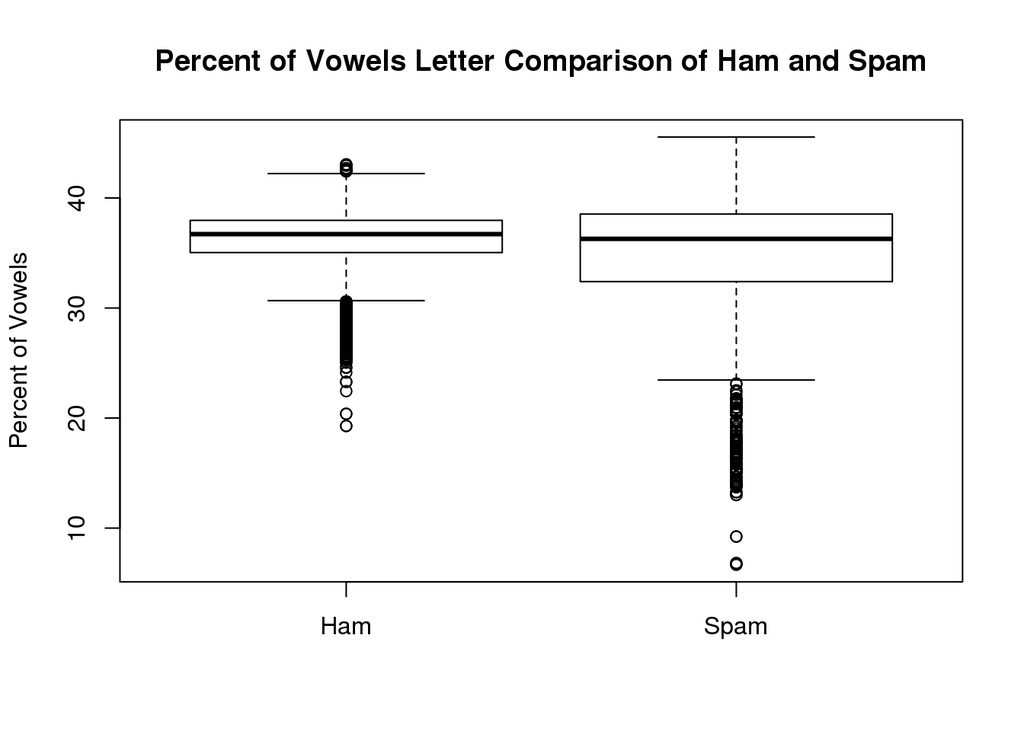

```r
boxplot(ham$VowelPerc,spam$VowelPerc, main = 'Percent of Vowels Letter Comparison of Ham and Spam',
        names=c('Ham','Spam'), ylab = 'Percent of Vowels')
```

From the boxplot shown above, the difference between ham and spam is not significant, either based on the mean difference or the range difference. Also, there is no significantly different in space between these two boxplots, and big portion of these two boxplots is overlapping. Thus, I believe that it is not a useful feature to classify ham and spam.

# Exercise 2

```r
avgLength=function(msgWords){
  avgs=mean(sapply(msgWords,function(msgWord){nchar(msgWord, keepNA=TRUE)}))
}
avg=sapply(msgWordsList, avgLength)
mean(avg)
```

```
## [1] 5.835972
```

```r
range(avg)
```

```
## [1]  2.816327 26.000000
```

```r
wordLen = emailDF$avgWordLen
mean(wordLen)
```

```
## [1] 4.488554
```

```r
range(wordLen)
```

```
## [1]  1.363072 26.000000
```

Firstly, the technique with findMsgWords use the stopwords, such as or, yes, which, and the findMsgWords will remove those words from the text, which has the potential influence to higher the average of the length (5.835972 > 4.488554).

Plus, the algorithm of findMsgWords use the unique() function, so it gets rid of the repetitive words, so there might be some chance to affect the average words length.

Also the range of both part is different as shown above, which (2.82, 26.0) for findMsgWords and avgLength: (1.36, 26.0)

Overall, based on the analysis, we are unlikely use findMsgWords function to find the average length.

# Exercise 3

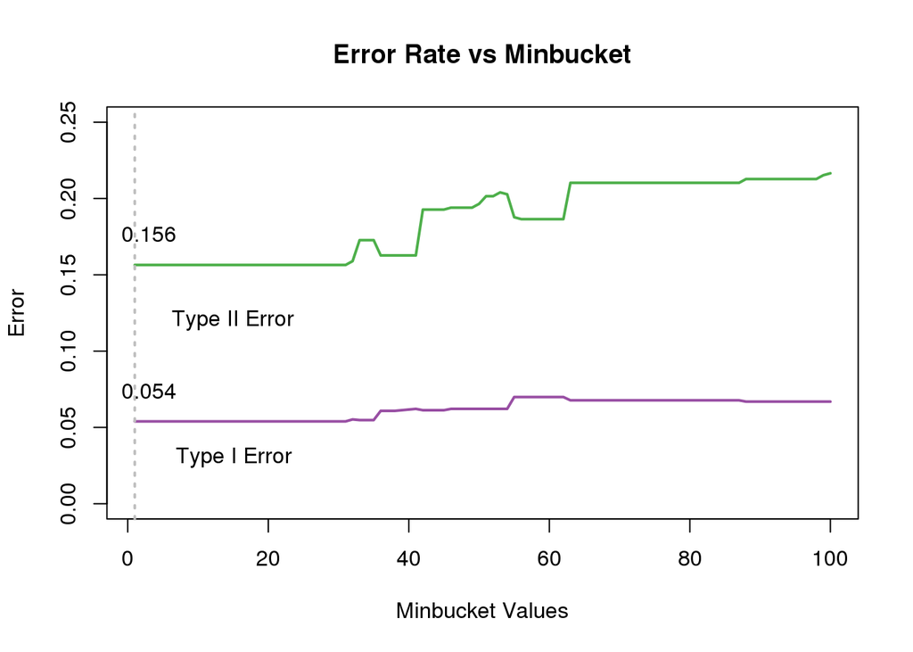

```r
set.seed(418910)
library(rpart)
setupRpart = function(data) {
  logicalVars = which(sapply(data, is.logical))
  facVars = lapply(data[ , logicalVars],
                   function(x) {
                     x = as.factor(x)
                     levels(x) = c("F", "T")
                     x
                   })
  cbind(facVars, data[ , - logicalVars])
}

# Process the email data frame.
emailDFrp = setupRpart(emailDF)

numSpam = sum(emailDFrp$isSpam=='T')
numHam = sum(emailDFrp$isSpam=='F')
# Obtain the Type I and Type II error rates from these fittings.

testSpamIdx = sample(numSpam, size = floor(numSpam/3))
testHamIdx = sample(numHam, size = floor(numHam/3))

testDF =
  rbind( emailDFrp[ emailDFrp$isSpam == "T", ][testSpamIdx, ],
         emailDFrp[emailDFrp$isSpam == "F", ][testHamIdx, ] )
trainDF =
  rbind( emailDFrp[emailDFrp$isSpam == "T", ][-testSpamIdx, ],
         emailDFrp[emailDFrp$isSpam == "F", ][-testHamIdx, ])


# Fit the recursive partitioning model for spam as a function of all variables in the data frame.
rpartFit = rpart(isSpam ~ ., data = trainDF, method = "class")

complexityVals = c(seq(1,100,1))
fits = lapply(complexityVals, function(x) {
  rpartObj = rpart(isSpam ~ . -VowelPerc , data = trainDF,
                   method="class",
                   control = rpart.control(minsplit = 1, minbucket = x ) )

  predict(rpartObj,
          newdata = testDF[ , names(testDF) != "isSpam"],
          type = "class")
})

spam = testDF$isSpam == "T"
numSpam = sum(spam)
numHam = sum(!spam)
errs = sapply(fits, function(preds) {
  typeI = sum(preds[ !spam ] == "T") / numHam
  typeII = sum(preds[ spam ] == "F") / numSpam
  c(typeI = typeI, typeII = typeII)
})

library(RColorBrewer)
cols = brewer.pal(9, "Set1")[c(3, 4, 5)]
plot(errs[1,] ~ complexityVals, type="l", col=cols[2],
     lwd = 2, ylim = c(0,0.25),
     ylab="Error", xlab="Minbucket Values", main = "Error Rate vs Minbucket")
points(errs[2,] ~ complexityVals, type="l", col=cols[1], lwd = 2)


text(x =c(15, 15.1), y = c(0.12, 0.03),
     labels=c("Type II Error", "Type I Error"))

minI = which(errs[1,] == min(errs[1,]))[1]
abline(v = complexityVals[minI], col ="grey", lty =3, lwd=2)

text(3, errs[1, minI]+0.02,
     formatC(errs[1, minI], digits = 2))
text(3, errs[2, minI]+0.02,
     formatC(errs[2, minI], digits = 3))
```

```r
which(errs[1,] == min(errs[1,])) #Minbucket value that has the minimum error rate.
```

```
##  [1]  1  2  3  4  5  6  7  8  9 10 11 12 13 14 15 16 17 18 19 20 21 22 23
## [24] 24 25 26 27 28 29 30 31
```

The trend of the plot is that the error for both Type 1 and type 2 increased along with the increasing of minbucket value except the first 31 values. As we could see from the plot and the function returns, with the value from 1 to 31 for minbucket, the error rate are the same, which is 0.054. However, if minbucket is 1, there might overfitting happening in this case, thus, we perfer the relatively safe approach, which we would choose 31 as the approprociate minbucket value.